# Gaussian approximation to Poisson mean problem

William R.P. Denault

2025-08-28

## Gaussian approximation to Poisson mean problem

This vignette examplify the benefit of the solbing the Poisson mean problem using informative prior. THis is an adaptation of the work of Dongyue Xie https://github.com/DongyueXie/vebpm/

We start by simulating some Poisson count with a sinusoidual intensity

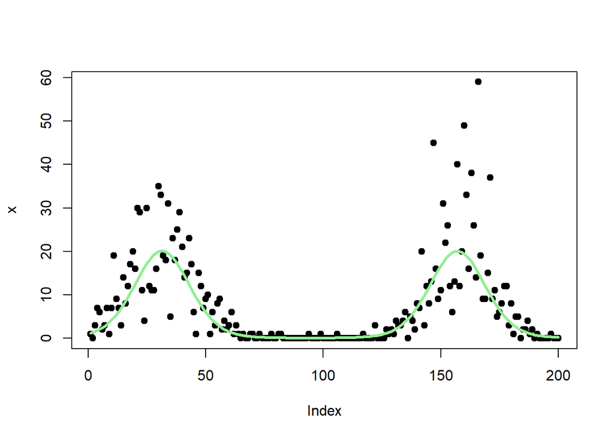

```r
library(fsusieR)
set.seed(1)
n =200

intensities= exp( 3*sin( 1:n/20)+0.1 + rnorm(n, sd=0.5) )
x = rpois(n,intensities)

plot(x,  pch=19)
lines(exp(3*sin( 1:n/20)), lwd=3, col="lightgreen")
```

Now let’s try to infer the underlying intensity using a Poisson Gaussian model where the prior is $N(b, \sigma^2)$ where both $b$ and $\sigma^2$ are learn via Empirical Bayes

```r
 tt= ebpm_normal(x)
tt$fitted_g
```

```
## $mean
## [1] 0.927291
##
## $var
## [1] 3.039285
```

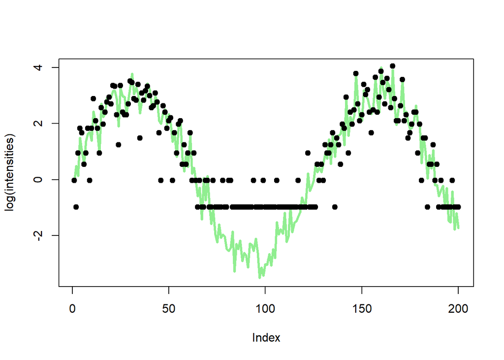

```r
plot(log(intensities), type="l",lwd=3, col="lightgreen")
points(tt$posterior$mean_log, pch=19)
```

Suppose we are an oracle and we know the prior

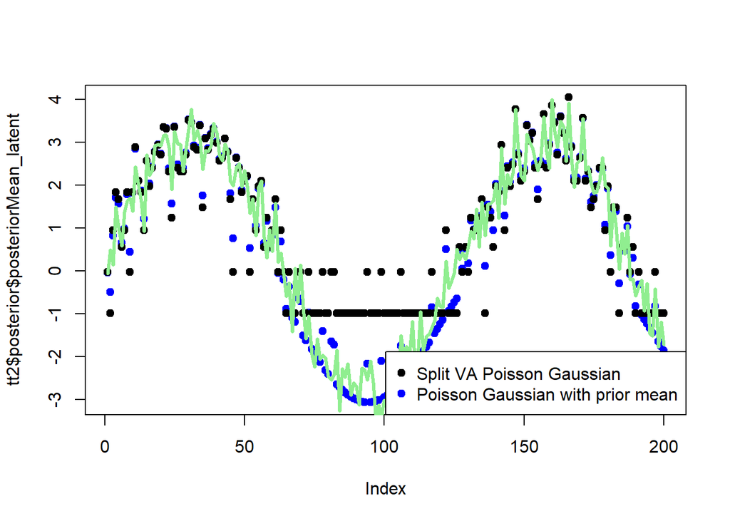

```r
 tt2= pois_mean_GP(x, prior_mean = 3*sin( 1:n/20) ,
                   prior_var = 1)

 plot(tt2$posterior$posteriorMean_latent, pch=19, col="blue")
points(tt$posterior$mean_log, pch=19)
 lines(log(intensities), ,lwd=3, col="lightgreen")

legend("bottomright", legend = c(  "Split VA Poisson Gaussian", "Poisson Gaussian with prior mean"), col = c(  "black" , "blue"), pch = 19)
```

```r
 mean((3*sin( 1:n/20)- tt$posterior$mean_log)^2)
```

```
## [1] 1.030747
```

```r
 mean((3*sin( 1:n/20)- tt2$posterior$posteriorMean_latent)^2)
```

```
## [1] 0.266005
```

#Comparison with log x+1 transform

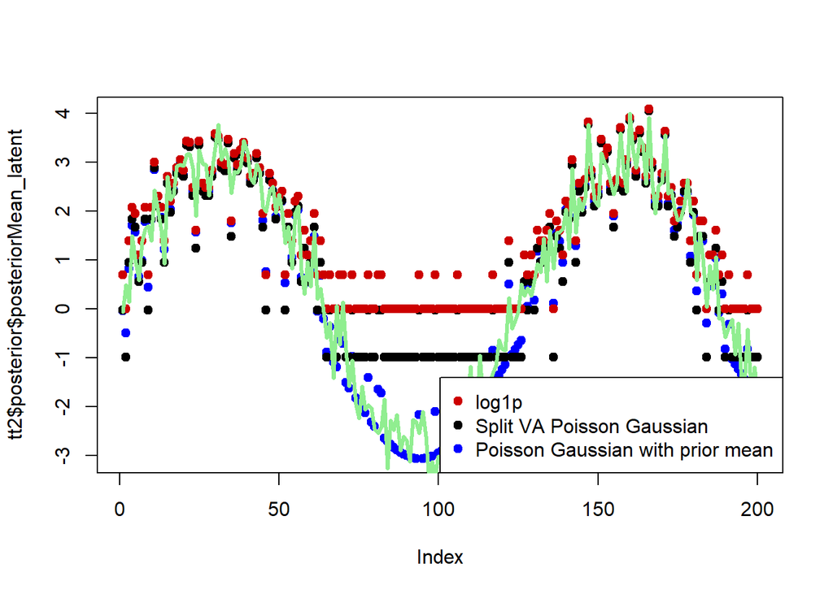

```r
 plot(tt2$posterior$posteriorMean_latent, pch=19, col="blue")
points(tt$posterior$mean_log, pch=19)
points(log(x+1),col="red3" ,pch=19)

 lines(log(intensities),lwd=3, col="lightgreen")

legend("bottomright", legend = c("log1p", "Split VA Poisson Gaussian", "Poisson Gaussian with prior mean"), col = c("red3", "black" , "blue"), pch = 19)
```

```r
 mean((3*sin( 1:n/20)- tt$posterior$mean_log)^2)
```

```
## [1] 1.030747
```

```r
 mean((3*sin( 1:n/20)- tt2$posterior$posteriorMean_latent)^2)
```

```
## [1] 0.266005
```

## Smoothing Possoin data via Split VA

Let now exemplifies how split VA work.

Let’s start building a starting guess for our prior mean and variance function. We start our first guess using a posterior mean for the log intensity of a Poisson Normal model. Then estimate the prior variance by computing the residual variance between the smoothed posterior log intensity and the posterior intensity

```r
s=rep(1, length(x))
init= ebpm_normal(x,s,g_init = list(mean=log(sum(x)/sum(s)),var=NULL),fix_g = c(T,F))
m =init$posterior$mean_log
sigma2 = var(  m - smashr::smash.gaus( m))
```

Then we iterate between learning the prior mean and then learn the posterior log intensity

```r
for ( k in 1:20){
    qb=smashr::smash.gaus(m,sqrt(sigma2), post.var = TRUE)
    Eb = qb$mu.est
    Eb2 = Eb^2+qb$mu.est.var

    opt = vga_pois_solver(init_val=m,
                          x=x,s=s,
                          beta= Eb ,
                          sigma2=sigma2,
                          tol=1e-05,
                          maxiter = 100)



    m = opt$m
    v = opt$v

    sigma2_new = mean(m^2+v+ Eb2+ 2* Eb -2*m*  Eb  )


}
```

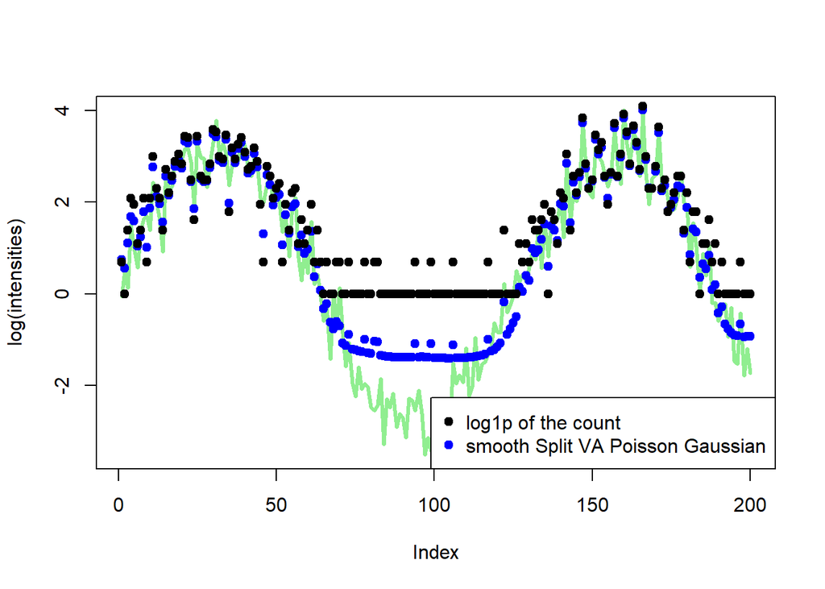

```r
plot(log(intensities),lwd=3, col="lightgreen" , type="l")
points(m, pch=19, col="blue")
points(log(x+1), pch=19 )
legend("bottomright", legend = c("log1p of the count", "smooth Split VA Poisson Gaussian" ), col = c( "black" , "blue"), pch = 19)
```